# hw6

Austin Melendez

2025-10-17

## 1

Use the following three lines of code to generate data for a linear regression.

```r
library(tidyverse)
library(faraway)
data(infmort)

summary(infmort)
```

```
##       region       income         mortality                  oil
##  Africa  :34   Min.   :  50.0   Min.   :  9.60   oil exports   : 9
##  Europe  :18   1st Qu.: 123.0   1st Qu.: 26.20   no oil exports:96
##  Asia    :30   Median : 334.0   Median : 60.60
##  Americas:23   Mean   : 998.1   Mean   : 89.05
##                3rd Qu.:1191.0   3rd Qu.:129.40
##                Max.   :5596.0   Max.   :650.00
##                                 NA's   :4
```

```r
mod <- lm(mortality ~ ., data=infmort)
summary(mod)
```

```
##
## Call:
## lm(formula = mortality ~ ., data = infmort)
##
## Residuals:
##     Min      1Q  Median      3Q     Max
## -156.00  -32.20   -4.44   13.65  488.82
##
## Coefficients:
##                     Estimate Std. Error t value Pr(>|t|)
## (Intercept)        2.152e+02  2.974e+01   7.234 1.19e-10 ***
## regionEurope      -1.015e+02  3.073e+01  -3.303 0.001351 **
## regionAsia        -4.589e+01  2.014e+01  -2.278 0.024977 *
## regionAmericas    -8.365e+01  2.180e+01  -3.837 0.000224 ***
## income            -5.290e-03  7.404e-03  -0.714 0.476685
## oilno oil exports -7.834e+01  2.891e+01  -2.710 0.007992 **
## ---
## Signif. codes:  0 '***' 0.001 '**' 0.01 '*' 0.05 '.' 0.1 ' ' 1
##
## Residual standard error: 77.36 on 95 degrees of freedom
##   (4 observations deleted due to missingness)
## Multiple R-squared:  0.3105, Adjusted R-squared:  0.2742
## F-statistic: 8.556 on 5 and 95 DF,  p-value: 1.015e-06
```

From this model using all other predictor values to predict `mortality`, all of our predictors are statistically significant besides `income`. However, our $R^2$ value is very low, 0.3105, which means it is only capturing ~31% of the data. Lets see if we can make that better.

Lets use AIC to optimize the model complexity vs significance.

```r
mod_step <- step(mod, k=2)
```

```
## Start:  AIC=884.2
## mortality ~ region + income + oil
##
##          Df Sum of Sq    RSS    AIC
## - income  1      3055 571546 882.74
## <none>                568491 884.20
## - oil     1     43936 612427 889.72
## - region  3    109016 677507 895.92
##
## Step:  AIC=882.74
## mortality ~ region + oil
##
##          Df Sum of Sq    RSS    AIC
## <none>                571546 882.74
## - oil     1     42197 613743 887.93
## - region  3    192877 764422 906.11
```

```r
summary(mod_step)
```

```
##
## Call:
## lm(formula = mortality ~ region + oil, data = infmort)
##
## Residuals:
##     Min      1Q  Median      3Q     Max
## -153.99  -31.55   -5.76   16.93  485.88
##
## Coefficients:
##                   Estimate Std. Error t value Pr(>|t|)
## (Intercept)         211.99      29.34   7.226 1.18e-10 ***
## regionEurope       -116.29      22.63  -5.138 1.46e-06 ***
## regionAsia          -47.87      19.90  -2.405   0.0181 *
## regionAmericas      -87.37      21.11  -4.138 7.51e-05 ***
## oilno oil exports   -76.45      28.72  -2.662   0.0091 **
## ---
## Signif. codes:  0 '***' 0.001 '**' 0.01 '*' 0.05 '.' 0.1 ' ' 1
##
## Residual standard error: 77.16 on 96 degrees of freedom
##   (4 observations deleted due to missingness)
## Multiple R-squared:  0.3068, Adjusted R-squared:  0.2779
## F-statistic: 10.62 on 4 and 96 DF,  p-value: 3.614e-07
```

The AIC slightly lowers when removing the `income` estimator. Let’s check the Box-Cox plot to verify our model assumptions.

```r
library(MASS)
```

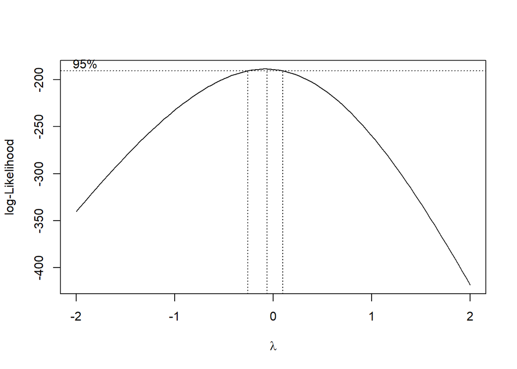

```r
bc <- boxcox(mod_step, plotit=TRUE)
```

Since the Box-Cox suggests lambda ~ 0, so we transform the response variable accordingly with a log transformation.

```r
mod_trans <- lm(log(mortality) ~ region + oil, data=infmort)
summary(mod_trans)
```

```
##
## Call:
## lm(formula = log(mortality) ~ region + oil, data = infmort)
##
## Residuals:
##      Min       1Q   Median       3Q      Max
## -1.60645 -0.41352  0.04289  0.33293  2.15326
##
## Coefficients:
##                   Estimate Std. Error t value Pr(>|t|)
## (Intercept)         5.2416     0.2522  20.782  < 2e-16 ***
## regionEurope       -2.0005     0.1946 -10.281  < 2e-16 ***
## regionAsia         -0.9179     0.1711  -5.365 5.61e-07 ***
## regionAmericas     -1.0037     0.1815  -5.530 2.76e-07 ***
## oilno oil exports  -0.3949     0.2469  -1.599    0.113
## ---
## Signif. codes:  0 '***' 0.001 '**' 0.01 '*' 0.05 '.' 0.1 ' ' 1
##
## Residual standard error: 0.6634 on 96 degrees of freedom
##   (4 observations deleted due to missingness)
## Multiple R-squared:  0.5495, Adjusted R-squared:  0.5307
## F-statistic: 29.27 on 4 and 96 DF,  p-value: 6.561e-16
```

THis has almost doubled our $R^2$ value. Next, lets check for influential points.

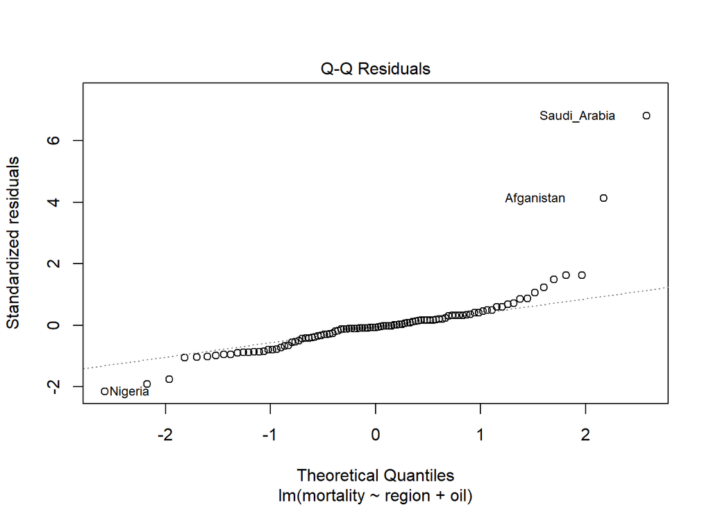

```r
plot(mod_step, 2)
```

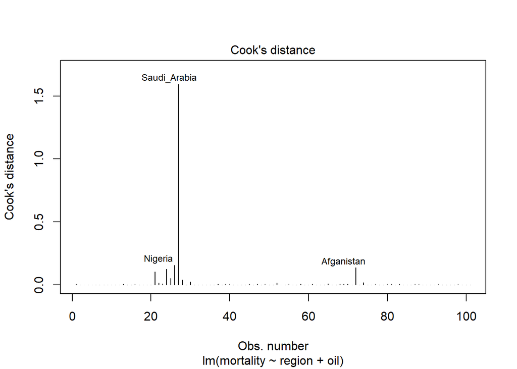

```r
plot(mod_step, 4)
```

```r
cooks <- cooks.distance(mod_step)
```

Let’s see which points have high leverage.

```r
hat <- hatvalues(mod_step)
which(hat > 2*mean(hat))
```

```
## Algeria             Ecuador             Indonesia           Iraq
##                  21                  22                  23                  24
## Libya               Nigeria             Saudi_Arabia        Venezuela
##                  25                  26                  27                  28
```

Let’s refit our model without the highly influential point, `Saudi Arabia`.

```r
infmort2 <- subset(infmort, row.names(infmort) != "Saudi_Arabia")
mod_reduced <- lm(log(mortality) ~ region + oil, data = infmort2)

summary(mod_reduced)
```

[output not shown]

This is our final model.

## 2

Let’s first convert the predictor variable `side` to factor.

```r
data(chredlin)
summary(chredlin)
```

```
##       race            fire           theft             age
##  Min.   : 1.00   Min.   : 2.00   Min.   :  3.00   Min.   : 2.00
##  1st Qu.: 3.75   1st Qu.: 5.65   1st Qu.: 22.00   1st Qu.:48.60
##  Median :24.50   Median :10.40   Median : 29.00   Median :65.00
##  Mean   :34.99   Mean   :12.28   Mean   : 32.36   Mean   :60.33
##  3rd Qu.:57.65   3rd Qu.:16.05   3rd Qu.: 38.00   3rd Qu.:77.30
##  Max.   :99.70   Max.   :39.70   Max.   :147.00   Max.   :90.10
##     involact          income       side
##  Min.   :0.0000   Min.   : 5.583   n:25
##  1st Qu.:0.0000   1st Qu.: 8.447   s:22
##  Median :0.4000   Median :10.694
##  Mean   :0.6149   Mean   :10.696
##  3rd Qu.:0.9000   3rd Qu.:11.989
##  Max.   :2.2000   Max.   :21.480
```

Let’s fit a model with side as a factor and fit the model with interactor to allow the slope to vary by side.

```r
mod_side <- lm(race ~ fire + theft + age + involact + income + side,
               data = chredlin)
summary(mod_side)
```

```
##
## Call:
## lm(formula = race ~ fire + theft + age + involact + income +
##     side, data = chredlin)
##
## Residuals:
##     Min      1Q  Median      3Q     Max
## -31.113 -11.881  -0.042  10.842  35.795
##
## Coefficients:
##             Estimate Std. Error t value Pr(>|t|)
## (Intercept)  78.1057    24.6669   3.166 0.002951 **
## fire         -0.2905     0.5598  -0.519 0.606651
## theft         0.3883     0.1656   2.345 0.024061 *
## age          -0.3027     0.1628  -1.859 0.070325 .
## involact     24.8963     7.3782   3.374 0.001655 **
## income       -5.3116     1.4894  -3.566 0.000957 ***
## sides        16.3368     6.0922   2.682 0.010596 *
## ---
## Signif. codes:  0 '***' 0.001 '**' 0.01 '*' 0.05 '.' 0.1 ' ' 1
##
## Residual standard error: 17.94 on 40 degrees of freedom
## Multiple R-squared:  0.7366, Adjusted R-squared:  0.697
## F-statistic: 18.64 on 6 and 40 DF,  p-value: 3.361e-10
```

```r
mod_side_int <- lm(race ~ (fire + theft + age + involact + income) * side,
                   data = chredlin)
summary(mod_side_int)
```

```
##
## Call:
## lm(formula = race ~ (fire + theft + age + involact + income) *
##     side, data = chredlin)
##
## Residuals:
##     Min      1Q  Median      3Q     Max
## -28.738  -8.889  -2.018   7.115  33.367
##
## Coefficients:
##                Estimate Std. Error t value Pr(>|t|)
## (Intercept)    52.67534   28.93192   1.821  0.07722 .
## fire            0.71039    0.66115   1.074  0.28996
## theft           0.08314    0.18904   0.440  0.66278
## age            -0.33677    0.19889  -1.693  0.09930 .
## involact       20.82995    8.37536   2.487  0.01780 *
## income         -2.76727    1.64219  -1.685  0.10087
## sides          86.56464   42.89828   2.018  0.05132 .
## fire:sides     -1.11387    1.11830  -0.996  0.32607
## theft:sides     1.06002    0.37255   2.845  0.00737 **
## age:sides      -0.09304    0.30493  -0.305  0.76207
## involact:sides -0.77093   12.77434  -0.060  0.95222
## income:sides   -7.85976    2.75740  -2.850  0.00727 **
## ---
## Signif. codes:  0 '***' 0.001 '**' 0.01 '*' 0.05 '.' 0.1 ' ' 1
##
## Residual standard error: 15.06 on 35 degrees of freedom
## Multiple R-squared:  0.8375, Adjusted R-squared:  0.7865
## F-statistic:  16.4 on 11 and 35 DF,  p-value: 1.043e-10
```

Now let’s compare these two models.

```r
anova(mod_side, mod_side_int)
```

```
## Analysis of Variance Table
##
## Model 1: race ~ fire + theft + age + involact + income + side
## Model 2: race ~ (fire + theft + age + involact + income) * side
##   Res.Df     RSS Df Sum of Sq      F   Pr(>F)
## 1     40 12869.1
## 2     35  7935.7  5    4933.4 4.3517 0.003484 **
## ---
## Signif. codes:  0 '***' 0.001 '**' 0.01 '*' 0.05 '.' 0.1 ' ' 1
```

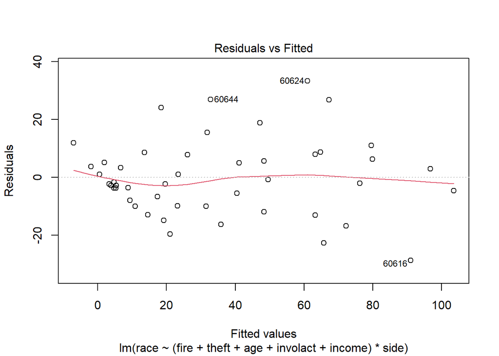

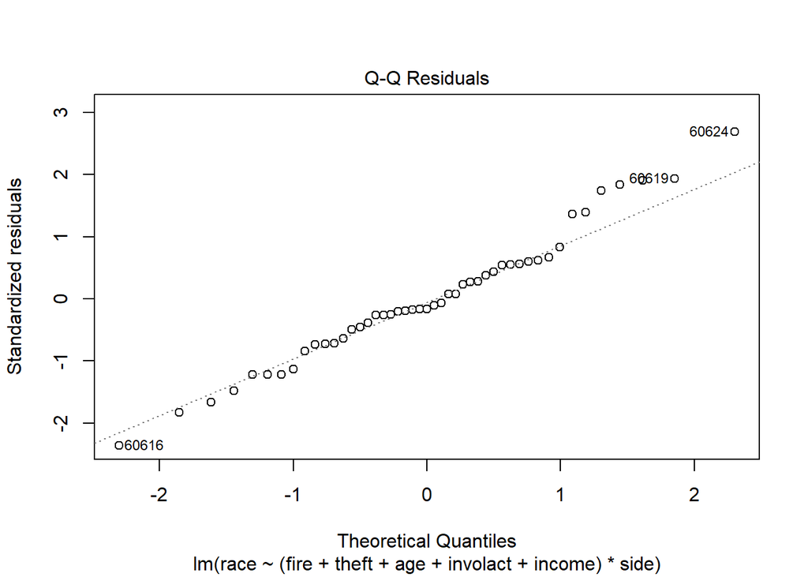

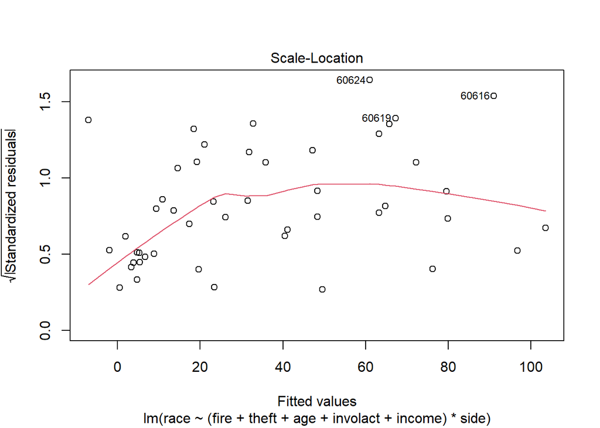

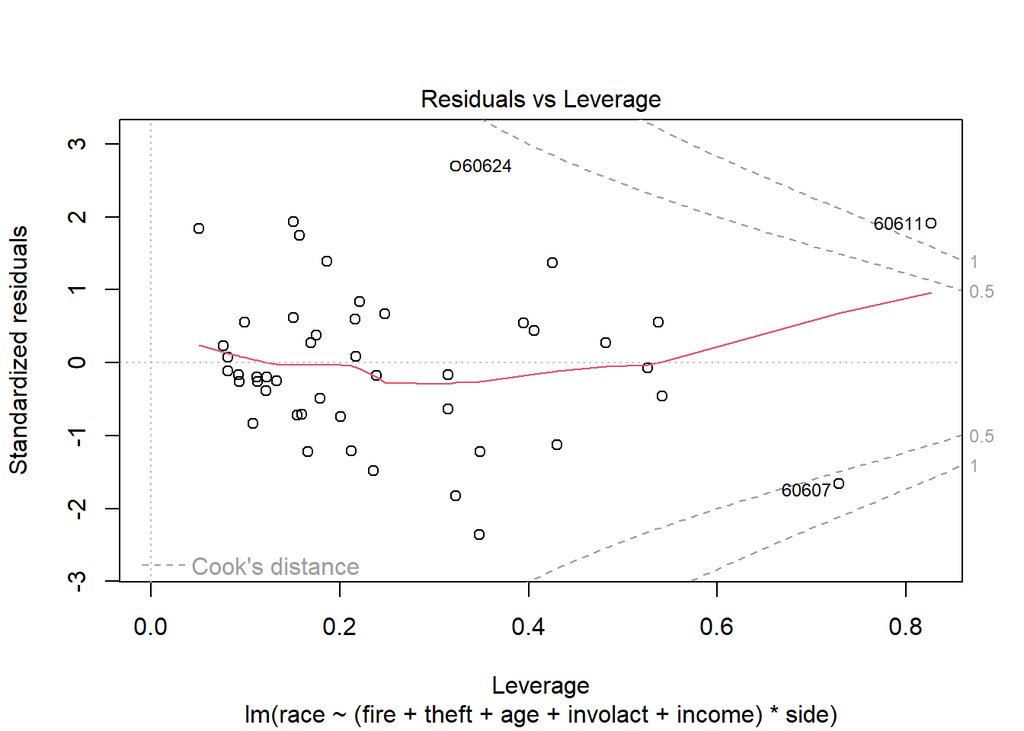

```r
plot(mod_side_int)
```

## 6

### A)

```r
data(clot)
summary(clot)
```

```
##       time            conc      lot
##  Min.   : 12.0   Min.   :  5   one:9
##  1st Qu.: 18.0   1st Qu.: 15   two:9
##  Median : 23.0   Median : 30
##  Mean   : 32.5   Mean   : 40
##  3rd Qu.: 35.0   3rd Qu.: 60
##  Max.   :118.0   Max.   :100
```

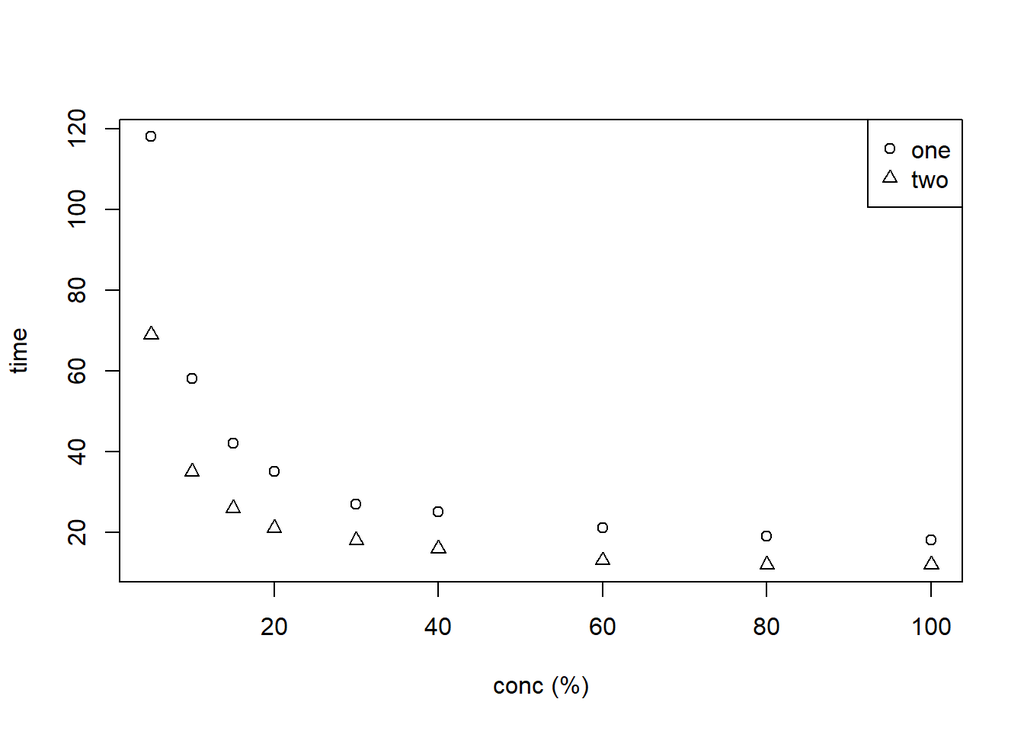

```r
clot$lot <- factor(clot$lot)  # ensure factor
plot(clot$conc, clot$time, pch=ifelse(clot$lot==levels(clot$lot)[1],1,2),
     xlab="conc (%)", ylab="time")
legend("topright", legend=levels(clot$lot), pch=1:2)
```

### B) Let’s check out our response and predictor varibales to see if we need to perfrom any transformations.

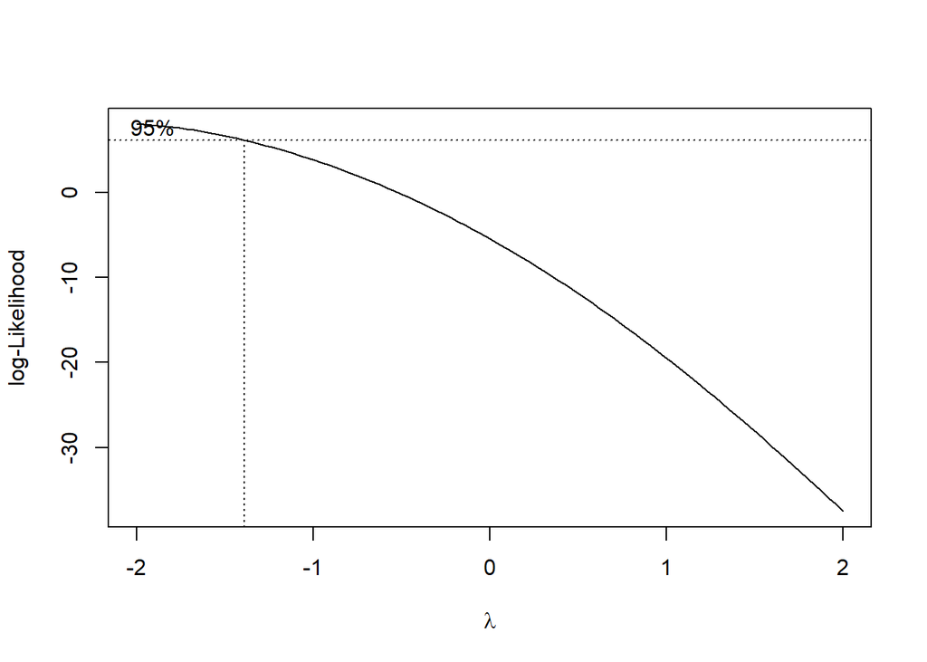

```r
mod <- lm(time ~ conc * lot, data = clot)
boxcox(mod, plotit = TRUE)
```

```r
mod_loglog <- lm(log(time) ~ log(conc) * lot, data = clot)
summary(mod_loglog)
```

```
##
## Call:
## lm(formula = log(time) ~ log(conc) * lot, data = clot)
##
## Residuals:
##      Min       1Q   Median       3Q      Max
## -0.16452 -0.10730 -0.04348  0.07614  0.25353
##
## Coefficients:
##                  Estimate Std. Error t value Pr(>|t|)
## (Intercept)       5.47806    0.18073  30.312 3.62e-14 ***
## log(conc)        -0.59704    0.05252 -11.367 1.87e-08 ***
## lottwo           -0.58179    0.25558  -2.276   0.0391 *
## log(conc):lottwo  0.03383    0.07428   0.455   0.6558
## ---
## Signif. codes:  0 '***' 0.001 '**' 0.01 '*' 0.05 '.' 0.1 ' ' 1
##
## Residual standard error: 0.1482 on 14 degrees of freedom
## Multiple R-squared:  0.9539, Adjusted R-squared:  0.944
## F-statistic: 96.47 on 3 and 14 DF,  p-value: 1.371e-09
```

Let’s also compare our models using an ANOVA table.

```r
anova(lm(log(time) ~ log(conc) + lot, data=clot), mod_loglog)
```

```
## Analysis of Variance Table
##
## Model 1: log(time) ~ log(conc) + lot
## Model 2: log(time) ~ log(conc) * lot
##   Res.Df     RSS Df Sum of Sq      F Pr(>F)
## 1     15 0.31207
## 2     14 0.30751  1 0.0045557 0.2074 0.6558
```

### D)

```r
shapiro.test(resid(mod_loglog))
```

```
##
##  Shapiro-Wilk normality test
##
## data:  resid(mod_loglog)
## W = 0.90304, p-value = 0.06491
```

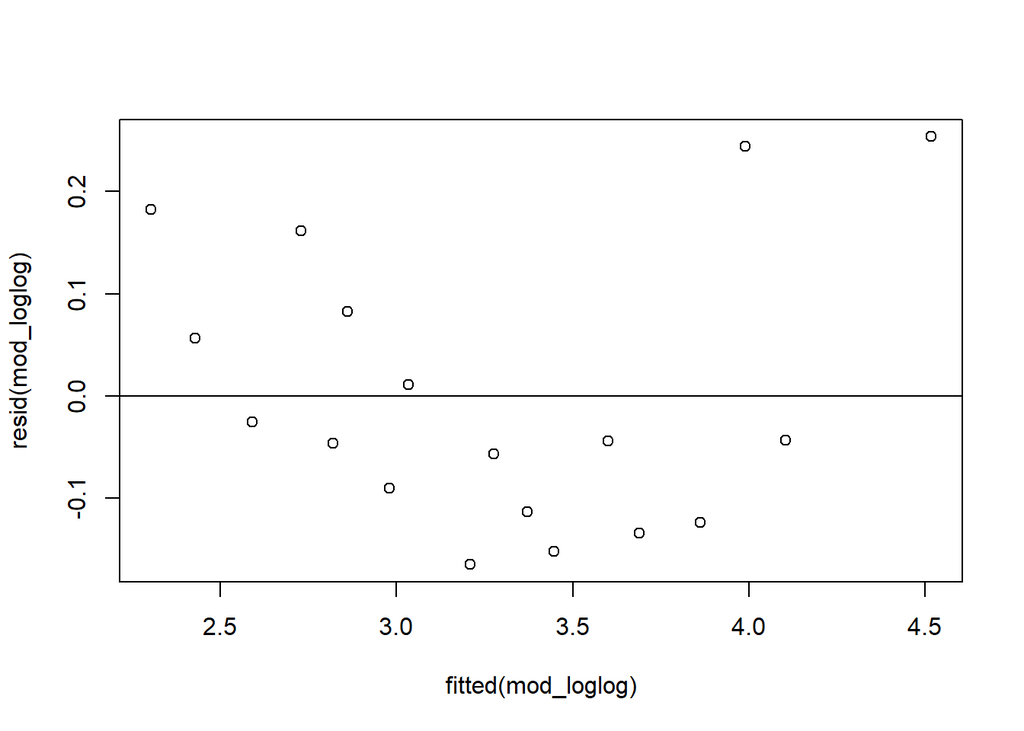

```r
plot(fitted(mod_loglog), resid(mod_loglog)); abline(h=0)
```

## 8

### A

```r
data(hips)
summary(hips)
```

```
##       fbef            faft            rbef            raft            grp
##  Min.   : 77.0   Min.   : 88.0   Min.   : 2.00   Min.   : 2.00   control:24
##  1st Qu.:108.0   1st Qu.:115.0   1st Qu.:20.25   1st Qu.:25.00   treat  :54
##  Median :115.0   Median :121.0   Median :25.00   Median :30.00
##  Mean   :114.5   Mean   :120.8   Mean   :24.85   Mean   :29.71
##  3rd Qu.:123.0   3rd Qu.:127.0   3rd Qu.:31.50   3rd Qu.:36.00
##  Max.   :135.0   Max.   :139.0   Max.   :48.00   Max.   :50.00
##
##     side        person
##  right:39   1      : 2
##  left :39   2      : 2
##             3      : 2
##             4      : 2
##             5      : 2
##             6      : 2
##             (Other):66
```

[figure not shown]

```r
plot(hips$fbef, hips$fafter, pch=ifelse(hips$grp=="control",1,2),
     xlab="flexion before", ylab="flexion after")
legend("bottomright", legend=c("control","treat"), pch=1:2)
```

### B)

```r
mod_ancova <- lm(faft ~ fbef + grp, data = hips)
summary(mod_ancova)
```

```
##
## Call:
## lm(formula = faft ~ fbef + grp, data = hips)
##
## Residuals:
##      Min       1Q   Median       3Q      Max
## -27.4050  -3.1586   0.0214   3.1850  21.3768
##
## Coefficients:
##             Estimate Std. Error t value Pr(>|t|)
## (Intercept) 59.86141    7.77213   7.702 4.39e-11 ***
## fbef         0.49008    0.06949   7.053 7.39e-10 ***
## grptreat     7.02553    1.77085   3.967 0.000165 ***
## ---
## Signif. codes:  0 '***' 0.001 '**' 0.01 '*' 0.05 '.' 0.1 ' ' 1
##
## Residual standard error: 6.976 on 75 degrees of freedom
## Multiple R-squared:  0.5327, Adjusted R-squared:  0.5202
## F-statistic: 42.74 on 2 and 75 DF,  p-value: 4.087e-13
```

```r
anova(mod_ancova)
```

```
## Analysis of Variance Table
##
## Response: faft
##           Df Sum Sq Mean Sq F value    Pr(>F)
## fbef       1 3394.4  3394.4  69.741  2.56e-12 ***
## grp        1  766.1   766.1  15.740 0.0001649 ***
## Residuals 75 3650.4    48.7
## ---
## Signif. codes:  0 '***' 0.001 '**' 0.01 '*' 0.05 '.' 0.1 ' ' 1
```

Let;s check if the slopes are different by treatment (`grp`).

```r
mod_anc_int <- lm(faft ~ fbef * grp, data = hips)
anova(mod_ancova, mod_anc_int)
```

```
## Analysis of Variance Table
##
## Model 1: faft ~ fbef + grp
## Model 2: faft ~ fbef * grp
##   Res.Df    RSS Df Sum of Sq      F Pr(>F)
## 1     75 3650.4
## 2     74 3632.1  1    18.267 0.3722 0.5437
```

### C)

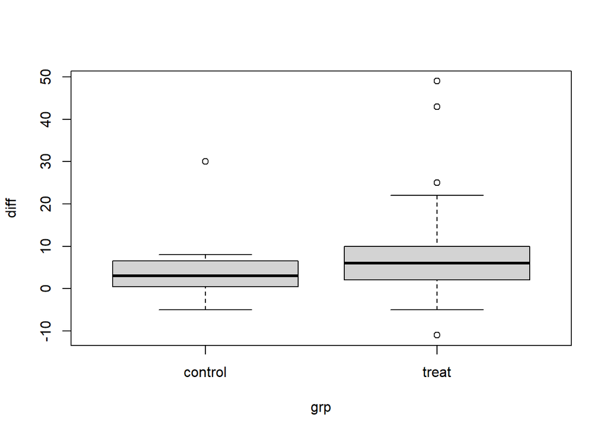

```r
hips$diff <- hips$faft - hips$fbef
boxplot(diff ~ grp, data = hips)
```

```r
t.test(diff ~ grp, data = hips, var.equal = FALSE)
```

```
##
##  Welch Two Sample t-test
##
## data:  diff by grp
## t = -1.901, df = 62.271, p-value = 0.06193
## alternative hypothesis: true difference in means between group control and group treat is not equal to 0
## 95 percent confidence interval:
##  -7.5694703  0.1898407
## sample estimates:
## mean in group control   mean in group treat
##              3.791667              7.481481
```

ANCOVA adjusts `fafter` for baseline and typically has better power if baseline correlates with outcome. While the difference approach directly tests change.

### D)

Let’s check for out highly influential points.

```r
which(hips$fbef < 90)
```

```
## [1] 49 50 70
```

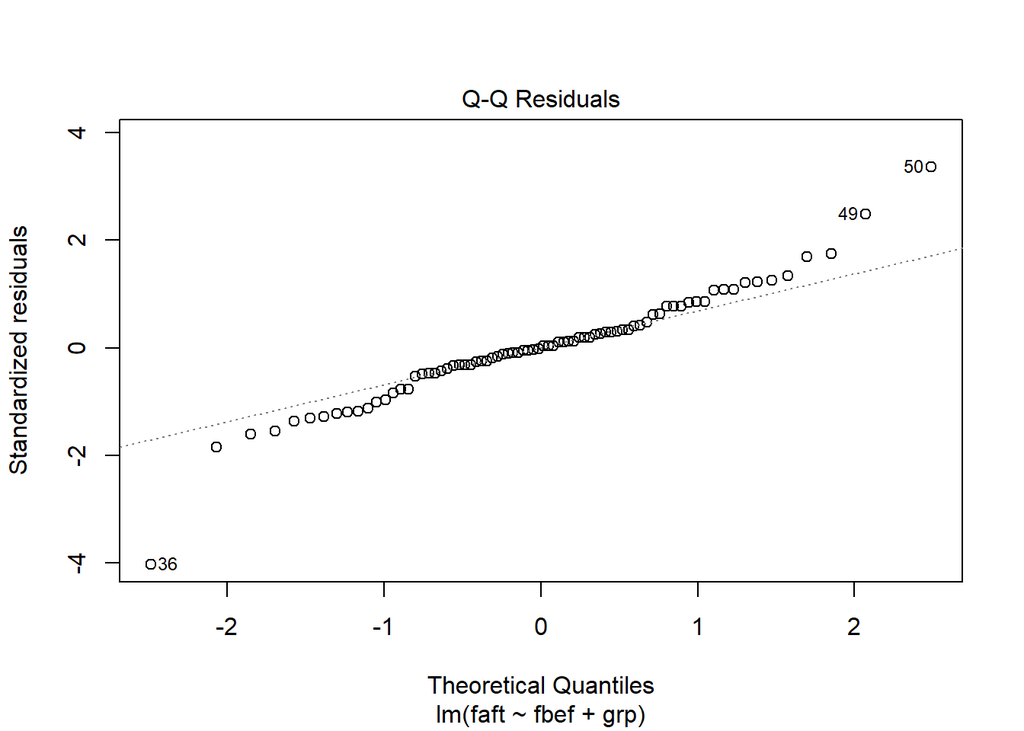

```r
plot(mod_ancova, 2)
```

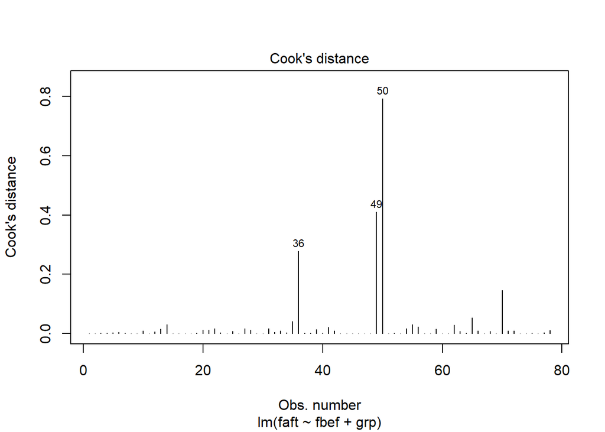

```r
plot(mod_ancova, 4)
```

We see points `49` and `50` are both very high Cook’s distance and high leverage. Let see which other points are considered high.

```r
cooks <- cooks.distance(mod_ancova)
which(cooks > 4/length(cooks))
```

```
## 36 49 50 65 70
## 36 49 50 65 70
```

So, let’s remove the outliers that are high leverage and highly influential and refit our model.

```r
hips2 <- hips[-c(49, 50), ]

mod_trim <- lm(faft ~ fbef + grp, data = hips2)
summary(mod_trim)
```

```
##
## Call:
## lm(formula = faft ~ fbef + grp, data = hips2)
##
## Residuals:
##      Min       1Q   Median       3Q      Max
## -22.5378  -3.1131   0.1256   3.0000  17.7680
##
## Coefficients:
##             Estimate Std. Error t value Pr(>|t|)
## (Intercept) 35.84053    7.95700   4.504 2.48e-05 ***
## fbef         0.70854    0.07152   9.907 3.78e-15 ***
## grptreat     4.55219    1.57682   2.887  0.00511 **
## ---
## Signif. codes:  0 '***' 0.001 '**' 0.01 '*' 0.05 '.' 0.1 ' ' 1
##
## Residual standard error: 5.95 on 73 degrees of freedom
## Multiple R-squared:  0.668,  Adjusted R-squared:  0.6589
## F-statistic: 73.45 on 2 and 73 DF,  p-value: < 2.2e-16
```

### E)

```r
confint(mod_trim)["grptreat",]
```

```
##    2.5 %   97.5 %
## 1.409588 7.694787
```

### G)

```r
hips_avg <- hips %>%
  group_by(person, grp) %>%
  summarize(
    fbef_mean = mean(fbef),
    faft_mean = mean(faft),
    diff_mean = mean(diff),
    .groups = "drop"
  )

mod_avg <- lm(faft_mean ~ fbef_mean + grp, data = hips_avg)

summary(mod_avg)
```

```
##
## Call:
## lm(formula = faft_mean ~ fbef_mean + grp, data = hips_avg)
##
## Residuals:
##      Min       1Q   Median       3Q      Max
## -18.7879  -2.9049   0.5299   2.3421  19.4625
##
## Coefficients:
##             Estimate Std. Error t value Pr(>|t|)
## (Intercept) 57.51895   10.84560   5.303 5.93e-06 ***
## fbef_mean    0.51139    0.09719   5.262 6.74e-06 ***
## grptreat     6.88617    2.31269   2.978  0.00517 **
## ---
## Signif. codes:  0 '***' 0.001 '**' 0.01 '*' 0.05 '.' 0.1 ' ' 1
##
## Residual standard error: 6.409 on 36 degrees of freedom
## Multiple R-squared:  0.5758, Adjusted R-squared:  0.5522
## F-statistic: 24.43 on 2 and 36 DF,  p-value: 1.981e-07
```

```r
confint(mod_avg)
```

```
##                  2.5 %     97.5 %
## (Intercept) 35.5230551 79.5148535
## fbef_mean    0.3142786  0.7084914
## grptreat     2.1958191 11.5765230
```